# Ancient cities and inscriptions

In this exercise you will map the ancient equivalent of Twitter data: the ancient inscriptions. Ancient people of class, education, and means liked to advertise their achievements and life milestones as well as their sorrows via the means of texts inscribed in stone. These epigraphic monuments were often placed near inhabited areas, roads, and gathering places where they were likely to attract the largest audience. The location of these self-expressions in space and time is a reasonable indicator of changing economic prosperity of the commissioning communities. In this exercise, you will explore how these ancient inscriptions spatially correspond to the distribution of ancient cities and settlements.

# Task 1: Load ancient cities and convert to sf object

John Hanson has created a dataset of all cities in the ancient Mediterranean and made it available online. You will download this dataset and convert it into an sf object in order to compare with the inscriptions on the basis of location.

- Use `read_csv()` to load `Hanson2016_Cities_OxREP.csv` dataset from the provided URL and assign it to `cities` object

```r
cities <- as.data.frame(read_csv("http://oxrep.classics.ox.ac.uk/oxrep/docs/Hanson2016/Hanson2016_Cities_OxREP.csv"))
```

… then reproject this data to EPSG 3035

```r
# Convert the table into an sf object on the basis of X and Y columns
cities_sf <- st_as_sf(cities, coords = c("Longitude (X)", "Latitude (Y)"))

# Define the projection of Lat/Long coordinates as EPSG 4326
cities_sf4326 <- st_set_crs(cities_sf, 4326)

# Transform the projection to a 2D projection using EPSG 3035
cities_sf3035 <- st_transform(cities_sf4326, crs = 3035)

# Verify the projection is 'projected' not 'geographic'
st_crs(cities_sf3035)
```

```
Coordinate Reference System:
  User input: EPSG:3035
  wkt:
PROJCS["ETRS89 / LAEA Europe",
    GEOGCS["ETRS89",
        DATUM["European_Terrestrial_Reference_System_1989",
            SPHEROID["GRS 1980",6378137,298.257222101,
                AUTHORITY["EPSG","7019"]],
            TOWGS84[0,0,0,0,0,0,0],
            AUTHORITY["EPSG","6258"]],
        PRIMEM["Greenwich",0,
            AUTHORITY["EPSG","8901"]],
        UNIT["degree",0.0174532925199433,
            AUTHORITY["EPSG","9122"]],
        AUTHORITY["EPSG","4258"]],
    PROJECTION["Lambert_Azimuthal_Equal_Area"],
    PARAMETER["latitude_of_center",52],
    PARAMETER["longitude_of_center",10],
    PARAMETER["false_easting",4321000],
    PARAMETER["false_northing",3210000],
    UNIT["metre",1,
        AUTHORITY["EPSG","9001"]],
    AUTHORITY["EPSG","3035"]]
```

We can verify that is it projected by seeing the projection attribute and that the crs is EPSG:3035

### Question 1:

*What are the measurement units of the `cities_sf3035` object?* As per default, the measurement unit will be in meters and looking at the data we can see that the unit is meter in most if not all of the entries.

# Task 2: Create a buffer around each city and inspect the result

As each city and inscription corresponds to a dot on the map, the best way to grab and review the inscriptions will be by creating a buffer around each city point and then selecting inscriptions on the basis of that.

- Create a buffer around the projected `cities` geometry with `st_buffer()` , setting the `dist` argument to the desired radius of 5000m.
- Plot the resulting buffer with city on top for quick review.

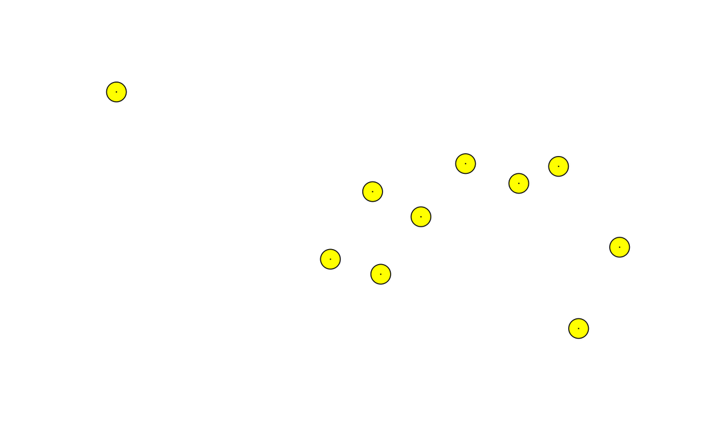

```r
# Make buffer of 5 km. Check the units of your object to correctly assign value
# to dist
cities_5km <- st_buffer(cities_sf3035, dist = 5000)

# Plot the first 10 buffers and cities to check result
plot(st_geometry(cities_5km)[1:10], col = "yellow")
plot(st_geometry(cities_sf3035)[1:10], pch = 20, cex = 0.1, add = TRUE)
```

# Task 3: Verify the city buffers are indeed 5km in radius

Well, a quick review may look ok, but you cannot be sure your buffers work well until you add them to a map with a scale. Verify that your buffers are as big as should be by plotting a sample with tmap and adding a scale of good resolution.

- Grab the first 10 cities and buffers with slice() function
- Load tmap package and plot the 10 cities and buffers with a scale of 0,10,20km. Add names and background for clarity. Do your buffers span 10km across or do they span the universe? (If the latter, recheck your CRS, units, and dist argument)

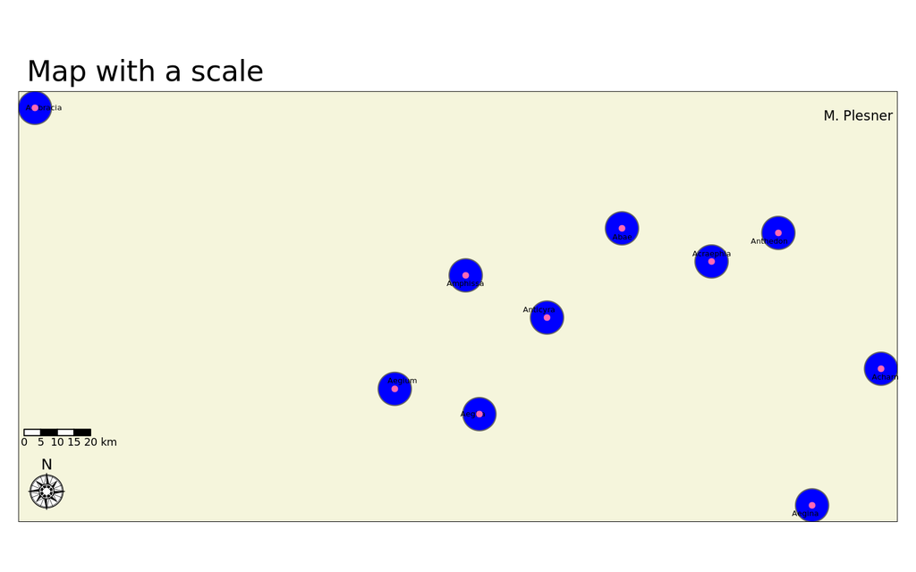

```r
# Grab the first 10 elements in the sf object and the buffer
ten_buffers <- cities_5km %>% slice(1:10)
ten_cities <- cities_sf3035 %>% slice(1:10)

# Create a quick tmap
library(tmap)
current.mode <- tmap_mode("plot")

tm_shape(ten_buffers) + tm_polygons(col = "blue") + tm_shape(ten_cities) + tm_text("Ancient Toponym",
    size = 0.4, auto.placement = 5) + tm_dots(col = "hotpink", size = 0.1) + tm_scale_bar(breaks = c(0,
    5, 10, 15, 20), text.size = 10, position = c("LEFT", "bottom")) + tm_compass(position = c("LEFT",
    "bottom"), type = "rose", size = 2) + tm_credits(position = c("RIGHT", "top"),
    text = "M. Plesner") + tm_layout(main.title = "Map with a scale", bg.color = "beige",
    inner.margins = c(0, 0, 0, 0))
```

If all went well, you should see a map, where the diameter of each city buffer corresponds to the 10km notch on the scale

# Task 4: Download ancient inscriptions and wrangle coordinates into shape

Let’s now look at some data that spatially co-occurs with these ancient places. Below is a link to an online dataset from the Epigraphic Database of Heidelberg of ancient inscriptions from one part of the ancient world. These inscriptions combine private and official expressions dedicated for personal reasons (death of a dear person) or public (dedication of a major building, placement of milestone, etc.).

The json dataset is hefty with some 12 thousand inscriptions and 74 variables. Coordinates are nested in a single column and may need wrangling. Do tasks deliberately in small steps after you test on subsets lest you overwhelm your R.

- Download the linked file with `download.file()` where you can find it.
- The inscriptions dataset is in `.json` format, which is becoming the dominant format for sharing data online. Use the `jsonlite::fromJSON` function in the library to load it back into R
- Next, use `as_tibble()` to convert into rectangular format.
- Check the column names looking for something that holds spatial data. There should be a `coordinates` column. Look at the column whether it holds meaningful coordinates.
- Separate the two values inside single coordinate column and create a separate longitude and a latitude column, which contain clean decimal numbers. You will need to clean up non-numeric characters en route. Make sure to keep the decimal point. Hint: there are lots of ways of getting clean decimal coordinates into two new columns, so feel free to diverge from the suggested course. Check out the `gsub()`, `grep()` and `str_extract()` functions to implement regular expressions in tidyverse pipeline.

```r
library(tidyverse)
library(jsonlite)
library(tidytext)

# Download the file and save as inscriptions.json (consider commenting out after
# you first run to avoid repeat downloading)
download.file("https://sciencedata.dk/public/b6b6afdb969d378b70929e86e58ad975/EDH_subset_2021-02-15.json",
    "data/inscriptions.json")

# Load it into R from wherever you put it, and convert into a tibble
list_json <- jsonlite::fromJSON("data/inscriptions.json")
inscriptions = as_tibble(list_json)

# Check the first couple lines and column names head(inscriptions$coordinates)
# colnames(inscriptions)

# I use regex to 'clean' the coordinates attribute before its separated using
# gsub. The regex finds everything that is not numbers 0-9, comma, and period,
# and replaces it with nothing.
i_sm <- inscriptions %>% slice(1:100) %>% mutate(coordinates = gsub("[^0-9.,]+",
    "", coordinates)) %>% separate(col = coordinates, into = c("longitude", "latitude"),
    sep = ",") %>% mutate(latitude = as.numeric(latitude), longitude = as.numeric(longitude))


leaflet() %>% addTiles() %>% addMarkers(lng = i_sm$longitude, lat = i_sm$latitude)
```

[interactive chart not shown]

Oooof. That was some serious wrangling!

### Question 2:

*Which part of the world are the inscriptions from?* We can see that they are from all from Italy.

# Task 5: Convert inscriptions into an sf object

Now that the hard work is done, let’s apply the wrangling to the full dataset and clean up the missing coordinates and outlier values.

- Not all coordinates are complete. Remove the rows with missing latitude or longitude
- Some incorrect points have sneaked in! Eliminate data with longitude smaller than 5 and larger than 20 degrees.
- Make the resulting `inscriptions` tibble into an sf object using the newly created and cleaned longitude and latitude column in the `coords` argument. The CRS of the data is 4326.
- Plot your data using st_geometry()

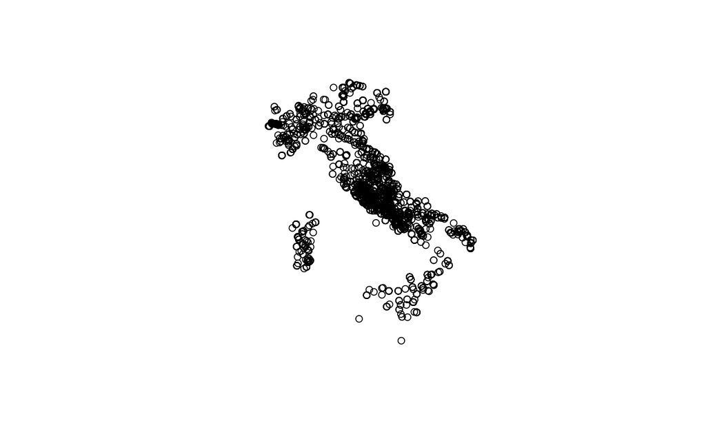

```r
# using the experimentation from last exercise i insert the same regex and
# subsitutes the mathces with nothing.  In the first filter i ask the function to
# only let a certain row pass, if neither the longitude or latitude is NA.
i <- inscriptions %>% mutate(coordinates = gsub("[^0-9.,]+", "", coordinates)) %>%
    separate(col = coordinates, into = c("longitude", "latitude"), sep = ",") %>%
    mutate(latitude = as.numeric(latitude), longitude = as.numeric(longitude)) %>%
    filter(!is.na(longitude) | !is.na(latitude)) %>% filter(latitude > 5 & longitude <
    20) %>% filter(longitude > 5 & longitude < 20)

# Create a sf object
insc_sf4326 <- st_as_sf(i, coords = c("longitude", "latitude"), crs = 4326)

# Plot
plot(st_geometry(insc_sf4326))
```

# Task 6: Select inscriptions that fall into the cities’ buffer

Now that you have both the cities and inscriptions in the same CRS, you can pick the inscriptions which fall within 5km radius of the ancient places in order to locate “urban” inscriptions. Use the inverse st_difference to locate “rural” inscriptions.

To reduce the computational intensity of the final intersection, it is a good idea to limit the dissolved city buffer object only to the area within the convex hull of the inscriptions. For the convex hull, you will need to combine the inscriptions into a MULTIPOINT feature using `st_union()`.

- Ensure that the spatial reference system in `cities_5km` buffer object and `inscriptions` is consistent.
- Create a convex hull for the inscriptions after combining them into a MULTIPOINT.
- Combine the city buffers into a single multipolygon
- Use `st_intersection()` to clip the inscriptions that fall within the buffer object and assign to `insc_urban` object
- Use `st_difference` flag to select inscriptions outside these buffers and create `insc_rural` object

```r
# Project the sf object into EPSG3035 so it is consistent with cities and their
# buffers
insc_sf3035 <- st_transform(insc_sf4326, crs = 3035)


# Create a convex hull around the inscriptions's points dissolved into a
# MULTIPOINT
insc_ch <- st_convex_hull(st_union(insc_sf3035))

# Create a buffer from a cluster of cities that fall within the convex hull
cities_it <- st_intersection(insc_ch, st_geometry(cities_5km))

# Dissolve the 399 buffers into a single MULTIPOLYGON buffer feature
c_buff <- st_union(cities_it)

c_buff
```

```
Geometry set for 1 feature
geometry type:  MULTIPOLYGON
dimension:      XY
bbox:           xmin: 4083521 ymin: 1432891 xmax: 5046056 ymax: 2603907
CRS:            EPSG:3035
```

```r
# Calculate the number of inscriptions in urban and rural areas. This may take a
# couple seconds
insc_urban <- st_intersection(insc_sf3035, c_buff)
insc_rural <- st_difference(insc_sf3035, c_buff)

nrow(insc_urban)
```

```
[1] 10462
```

```r
nrow(insc_rural)
```

```
[1] 1605
```

```r
nrow(insc_urban)/nrow(insc_rural)
```

```
[1] 6.51838
```

### Question 3:

*What is the ratio of urban to rural inscriptions?* The last 3 lines in the code prints the number of rows in the two variables aswell as the ratio. Looking at the ratio, we can see that there is a much higher amount of inscriptions in urban areas rather than rural.